# Reference Airline Satisfaction

**Customer Ratings Distribution**

[output not shown]

[output cut: 15 more lines]

[output not shown]

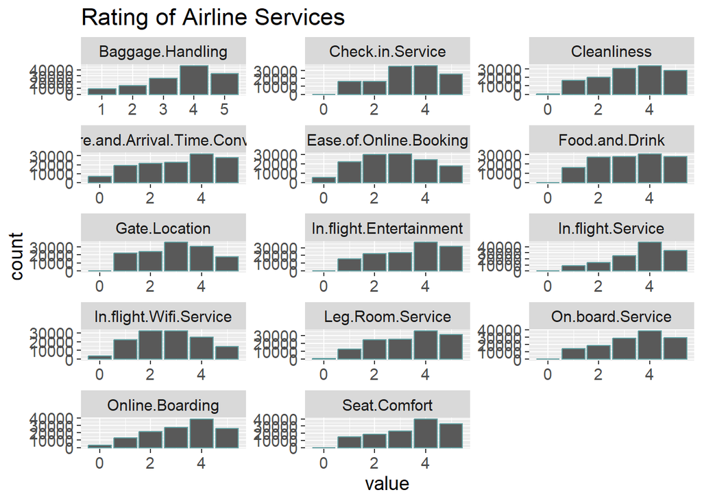

```r
ds_rating <- subset(ds, select=c("In.flight.Wifi.Service", "Departure.and.Arrival.Time.Convenience","Ease.of.Online.Booking", "Gate.Location", "Food.and.Drink", "Online.Boarding", "Seat.Comfort", "In.flight.Entertainment", "On.board.Service", "Leg.Room.Service", "Baggage.Handling", "Check.in.Service", "In.flight.Service","Cleanliness"))
options(repr.plot.width = 14, repr.plot.height = 8)

ds_rating %>%
  gather()%>%
  ggplot(aes(value, fill = value)) +
    facet_wrap(~ key, scales = "free", ncol=3) +
    geom_histogram(stat="count", col="cadetblue")+
  scale_fill_brewer(palette = "Blues")+
  labs(title="Rating of Airline Services")+
theme(text= element_text(size=14))
```

**Categorical Variables**

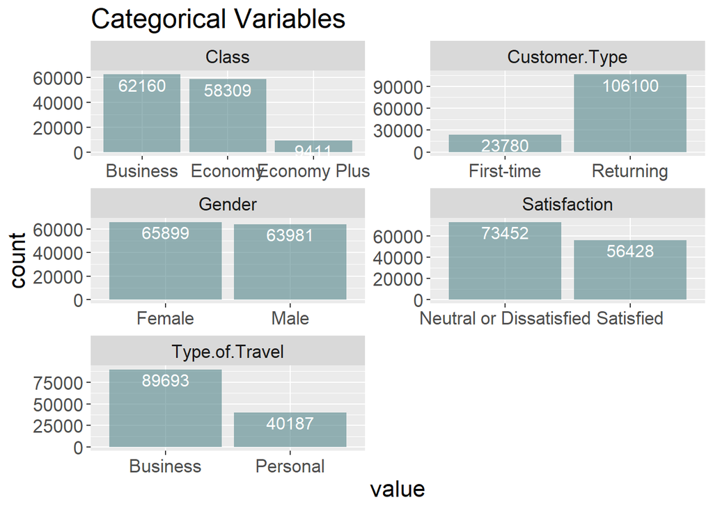

```r
# Select categorical columns
ds_cat <- subset(ds, select = c("Gender", "Customer.Type", "Type.of.Travel", "Class", "Satisfaction"))

# Convert Satisfaction to a factor
ds_cat$Satisfaction <- as.factor(ds_cat$Satisfaction)

# Reshape data from wide to long format
ds_long <- ds_cat %>%
  pivot_longer(cols = everything(), names_to = "key", values_to = "value")

# Ensure 'key' is a factor
ds_long$key <- as.factor(ds_long$key)

# Plot using ggplot2
ggplot(ds_long, aes(value)) +
  geom_histogram(stat = "count", fill = "cadetblue4", alpha = 0.6) +
  facet_wrap(~ key, ncol = 2, scales = "free") +
  labs(title = "Categorical Variables") +
  stat_count(aes(y = ..count.., label = ..count..), geom = "text",
             vjust = 1.3, size = 4.2, color = "white") +
  theme(text = element_text(size = 16))
```

**Observations**

- The gender ratio is quite balanced with almost equal numbers of male and female passengers
- Loyal customers are much higher in number than disloyal customers
- While the difference is not too high, more passengers are dissatisfied or neutral than satisfied
- Passengers who travel for business are more than the double of personal travel passengers. This explains why maximum passengers go for business class.

**Customer Loyalty and Satisfaction**

Do loyal customers report satisfaction more than disloyal customers?

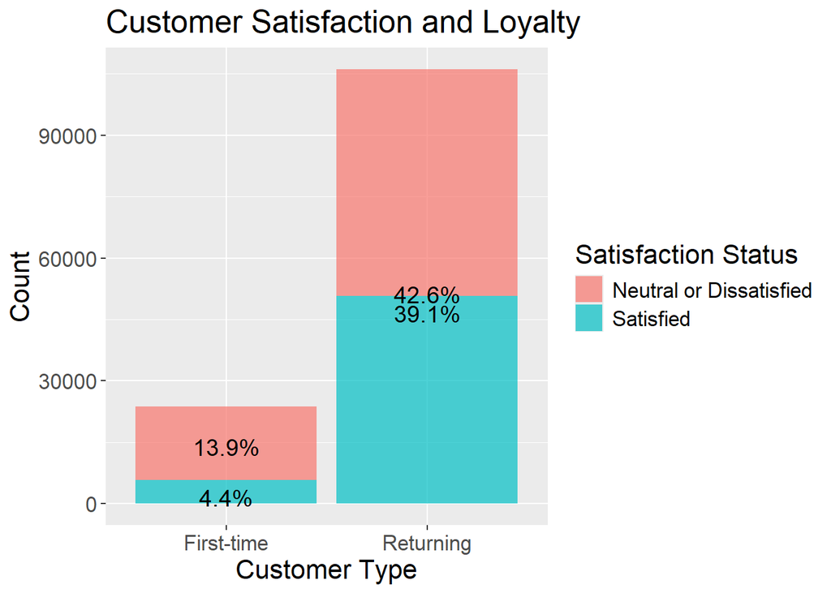

```r
options(repr.plot.width = 14, repr.plot.height = 8)
ggplot(ds, aes(x=`Customer.Type`, fill = `Satisfaction`))+
  geom_bar(alpha=0.7)+
  geom_text(aes(label= scales::percent((..count..)/sum(..count..))), stat="count",
        vjust = 1.5, size=5)+
  scale_fill_discrete(name = "Satisfaction Status", labels=c("Neutral or Dissatisfied", "Satisfied"))+
  labs(x="Customer Type", y="Count", title="Customer Satisfaction and Loyalty ")+
  theme(legend.position="right",text= element_text(size=16) )
```

**Observation**

**Convenience of Arrival/Departure and Satisfaction** With increasing conveneince of arrival/departure time, the number of satisfied customers should gradually increase with the rating. The opposite trend should be observed for dissatisfied customers.

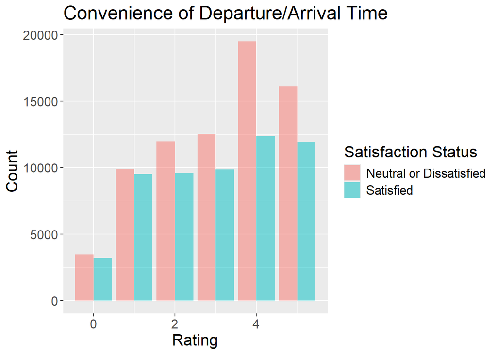

```r
options(repr.plot.width = 14, repr.plot.height = 8)
ggplot(ds, aes(x=`Departure.and.Arrival.Time.Convenience`, fill =`Satisfaction`))+
  geom_bar(position="dodge", alpha=0.5)+
  labs(x="Rating", y="Count", title="Convenience of Departure/Arrival Time")+
  scale_fill_discrete(name = "Satisfaction Status", labels=c("Neutral or Dissatisfied", "Satisfied"))+
  theme(legend.position="right", text= element_text( size = 16))
```

**Observation**

**Customer Satisfaction and Ease of Online Booking**

Since increase in the ease of online booking tends to increase satisfaction, as indicated by logistic regression analysis, the number of satisfied customers should should be higher than dissatisfied/neutral customers for the highest rating (=5) in ease of online booking.

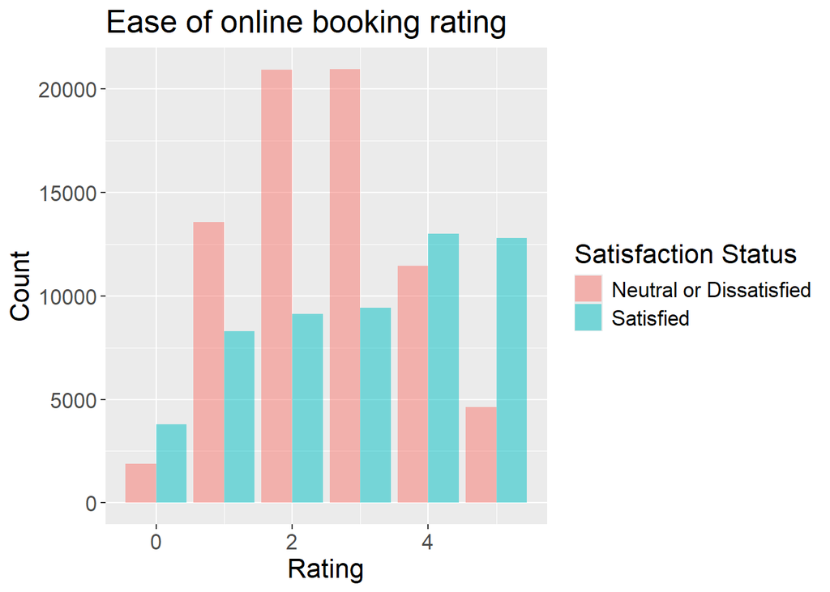

```r
options(repr.plot.width = 14, repr.plot.height = 8)
ggplot(ds, aes(x=`Ease.of.Online.Booking`, fill =`Satisfaction`))+
  geom_bar(position="dodge", alpha=0.5)+
  labs(x="Rating", y="Count", title="Ease of online booking rating")+
  scale_fill_discrete(name = "Satisfaction Status", labels=c("Neutral or Dissatisfied", "Satisfied"))+
  theme(legend.position="right", text= element_text( size = 16))
```

**Observation**